# BIS 15L Midterm 2

Qianyu Jin

2022-02-22

## Instructions

Answer the following questions and complete the exercises in RMarkdown. Please embed all of your code and push your final work to your repository. Your code should be organized, clean, and run free from errors. Be sure to **add your name** to the author header above. You may use any resources to answer these questions (including each other), but you may not post questions to Open Stacks or external help sites. There are 10 total questions.

Make sure to use the formatting conventions of RMarkdown to make your report neat and clean! Your plots should use consistent aesthetics throughout.

This exam is due by **12:00p on Tuesday, February 22**.

```r
library(tidyverse)
library(janitor)
library(here)
library(naniar)
library("gapminder")
library(RColorBrewer)
library(paletteer)
```

## Gapminder

For this assignment, we are going to use data from [gapminder](https://www.gapminder.org/). Gapminder includes information about economics, population, social issues, and life expectancy from countries all over the world. We will use three data sets, so please load all three as separate objects.

1. population_total.csv
2. income_per_person_gdppercapita_ppp_inflation_adjusted.csv
3. life_expectancy_years.csv

```r
population <- read_csv(here("midterm2", "data", "population_total.csv"))
income_per_person <- read_csv(here("midterm2", "data", "income_per_person_gdppercapita_ppp_inflation_adjusted.csv"))
life_expectancy <- read_csv(here("midterm2", "data", "life_expectancy_years.csv"))
```

1. (3 points) Once you have an idea of the structure of the data, please make each data set tidy (hint: think back to pivots) and store them as new objects. You will need both the original (wide) and tidy (long) data!

```r
summary(population)
```

[output not shown]

[output cut: 624 more lines]

[output not shown]

```r
summary(income_per_person)
```

[output not shown]

[output cut: 344 more lines]

[output not shown]

```r
summary(life_expectancy)
```

[output not shown]

[output cut: 553 more lines]

[output not shown]

```r
population_tidy <- population %>%
  pivot_longer(!country,
               names_to = "year",
               values_to = "population")
```

```r
income_per_person_tidy <- income_per_person %>%
  pivot_longer(!country,
               names_to = "year",
               values_to = "income")
```

```r
life_expectancy_tidy <- life_expectancy %>%
  pivot_longer(!country,
               names_to = "year",
               values_to = "life_expectancy")
```

2. (1 point) How many different countries are represented in the data? Provide the total number and their names. Since each data set includes different numbers of countries, you will need to do this for each one.

```r
population_tidy %>%
  summarise(total_contries = n_distinct(country))
```

```
## # A tibble: 1 × 1
##   total_contries
##            <int>
## 1            195
```

```r
income_per_person_tidy %>%
  summarise(total_countries = n_distinct(country))
```

```
## # A tibble: 1 × 1
##   total_countries
##             <int>
## 1             193
```

```r
life_expectancy_tidy %>%
  summarise(total_countries = n_distinct(country))
```

```
## # A tibble: 1 × 1
##   total_countries
##             <int>
## 1             187
```

## Life Expectancy

3. (2 points) Let’s limit the data to 100 years (1920-2020). For these years, which country has the highest average life expectancy? How about the lowest average life expectancy?

*Sweden has the highest average life expectancy.*

```r
life_expectancy_tidy %>%
  filter(year >= 1920 & year <= 2020) %>%
  group_by(country) %>%
  summarise(average_life_expectancy = mean(life_expectancy)) %>%
  arrange(desc(average_life_expectancy))
```

```
## # A tibble: 187 × 2
##    country        average_life_expectancy
##    <chr>                            <dbl>
##  1 Sweden                            73.5
##  2 Norway                            73.2
##  3 Netherlands                       73.0
##  4 Iceland                           72.9
##  5 Australia                         72.7
##  6 Switzerland                       72.7
##  7 Denmark                           71.9
##  8 Canada                            71.8
##  9 New Zealand                       71.4
## 10 United Kingdom                    71.1
## # … with 177 more rows
```

*Central African Republic has lowest average life expectancy.*

```r
life_expectancy_tidy %>%
  filter(year >= 1920, year <= 2020) %>%
  group_by(country) %>%
  summarise(average_life_expectancy = mean(life_expectancy)) %>%
  arrange(average_life_expectancy)
```

```
## # A tibble: 187 × 2
##    country                  average_life_expectancy
##    <chr>                                      <dbl>
##  1 Central African Republic                    41.8
##  2 Mali                                        41.8
##  3 Ethiopia                                    42.6
##  4 Sierra Leone                                42.6
##  5 Guinea-Bissau                               42.6
##  6 Burundi                                     42.8
##  7 Malawi                                      42.8
##  8 Uganda                                      43.3
##  9 Eritrea                                     43.4
## 10 Yemen                                       43.6
## # … with 177 more rows
```

4. (3 points) Although we can see which country has the highest life expectancy for the past 100 years, we don’t know which countries have changed the most. What are the top 5 countries that have experienced the biggest improvement in life expectancy between 1920-2020?

*Kuwait, Kyrgyz Republic, Turkmenistan, South Korea, Tajikistan are the top 5 countries that have experienced the biggest improvement in life expectancy between 1920-2020.*

```r
life_expectancy_tidy %>%
  filter(year == 1920 | year == 2020) %>%
  pivot_wider(
    names_from = "year",
    names_glue = "yr_{year}",
    values_from = "life_expectancy") %>%
  mutate(improved_life_expectancy = yr_2020 - yr_1920) %>%
  arrange(desc(improved_life_expectancy))
```

```
## # A tibble: 187 × 4
##    country         yr_1920 yr_2020 improved_life_expectancy
##    <chr>             <dbl>   <dbl>                    <dbl>
##  1 Kuwait             26.6    83.4                     56.8
##  2 Kyrgyz Republic    16.6    73.1                     56.5
##  3 Turkmenistan       15.2    70.5                     55.3
##  4 South Korea        28.2    83.2                     55
##  5 Tajikistan         16.7    71                       54.3
##  6 Nicaragua          25.3    79.5                     54.2
##  7 Kazakhstan         19.3    73.1                     53.8
##  8 Russia             20.5    72.7                     52.2
##  9 Israel             32      83.4                     51.4
## 10 Iran               26.8    78                       51.2
## # … with 177 more rows
```

5. (3 points) Make a plot that shows the change over the past 100 years for the country with the biggest improvement in life expectancy. Be sure to add appropriate aesthetics to make the plot clean and clear. Once you have made the plot, do a little internet searching and see if you can discover what historical event may have contributed to this remarkable change.

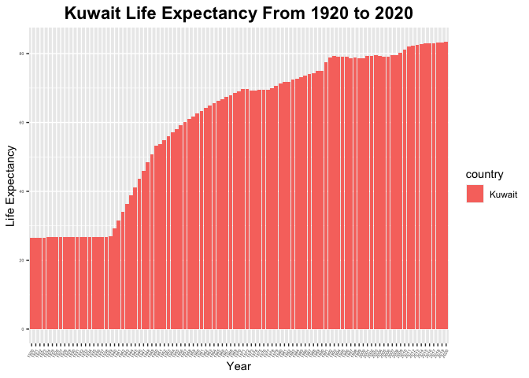

```r
life_expectancy_tidy %>%
  filter(country=="Kuwait") %>%
  filter(between(year, 1920, 2020)) %>%
  ggplot(aes(x=year, y=life_expectancy, fill=country))+
  geom_col()+
  theme(axis.text.x = element_text(angle = 60, hjust = 1))+
  theme(plot.title = element_text(size = rel(1.5), face='bold', hjust = 0.5))+
  theme(axis.text = element_text(size = 4))+
  labs(title = "Kuwait Life Expectancy From 1920 to 2020",
       x = "Year",
       y = "Life Expectancy")
```

## Population Growth

6. (3 points) Which 5 countries have had the highest population growth over the past 100 years (1920-2020)?

*India, China, Indonesia, US, Pakistan have had the highest population growth over the past 100 years.*

```r
population_tidy %>%
  filter(year == 1920 | year == 2020) %>%
  pivot_wider(names_from = "year",
              names_glue = "yr_{year}",
              values_from = "population") %>%
  mutate(pgrowth = yr_2020 - yr_1920) %>%
  arrange(desc(pgrowth))
```

```
## # A tibble: 195 × 4
##    country         yr_1920    yr_2020    pgrowth
##    <chr>             <dbl>      <dbl>      <dbl>
##  1 India         317000000 1380000000 1063000000
##  2 China         472000000 1440000000  968000000
##  3 Indonesia      47300000  274000000  226700000
##  4 United States 111000000  331000000  220000000
##  5 Pakistan       21700000  221000000  199300000
##  6 Brazil         27600000  213000000  185400000
##  7 Nigeria        23300000  206000000  182700000
##  8 Bangladesh     27300000  165000000  137700000
##  9 Mexico         14800000  129000000  114200000
## 10 Philippines     9400000  110000000  100600000
## # … with 185 more rows
```

7. (4 points) Produce a plot that shows the 5 countries that have had the highest population growth over the past 100 years (1920-2020). Which countries appear to have had exponential growth?

*China and India appear to have had exponential growth.*

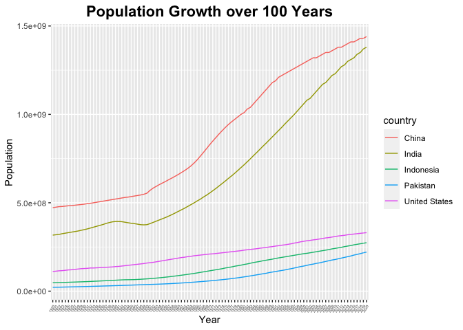

```r
population_tidy %>%
  filter(country %in% c("India","China","Indonesia","United States","Pakistan")) %>%
  filter(between(year, 1920, 2020)) %>%
  ggplot(aes(x=year, y=population, group=country , color=country))+
  geom_line()+
  theme(axis.text.x = element_text(angle = 60, hjust = 1, size=4))+
  theme(plot.title = element_text(size = rel(1.5), face='bold', hjust = 0.5))+
  labs(title = "Population Growth over 100 Years",
       x = "Year",
       y = "Population")
```

## Income

The units used for income are gross domestic product per person adjusted for differences in purchasing power in international dollars.

8. (4 points) As in the previous questions, which countries have experienced the biggest growth in per person GDP. Show this as a table and then plot the changes for the top 5 countries. With a bit of research, you should be able to explain the dramatic downturns of the wealthiest economies that occurred during the 1980’s.

*Qatar, Luxembourg, Singapore, Brunei, Ireland have experienced the biggest growth in per person GDP. Between 1980 and 1982 the economy experienced a deep recession, caused by the Iranian Revolution which caused a disruption to the global oil supply. This affected many countries world wide.*

```r
income_per_person_tidy %>%
  filter(year == 1920 | year == 2020) %>%
  pivot_wider(names_from = "year",
              names_glue = "yr_{year}",
              values_from = "income") %>%
  mutate(income_growth = yr_2020 - yr_1920) %>%
  arrange(desc(income_growth))
```

```
## # A tibble: 193 × 4
##    country              yr_1920 yr_2020 income_growth
##    <chr>                  <dbl>   <dbl>         <dbl>
##  1 Qatar                   2300  116000        113700
##  2 Luxembourg              5730   95100         89370
##  3 Singapore               2440   90500         88060
##  4 Brunei                  2130   75100         72970
##  5 Ireland                 5170   74100         68930
##  6 United Arab Emirates    2090   65300         63210
##  7 Kuwait                  2350   64300         61950
##  8 Norway                  8960   67500         58540
##  9 Monaco                  6630   62000         55370
## 10 San Marino              3280   57900         54620
## # … with 183 more rows
```

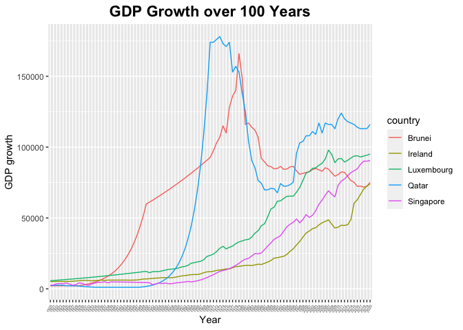

```r
income_per_person_tidy %>%
  filter(country %in% c("Qatar","Luxembourg","Singapore","Brunei","Ireland")) %>%
  filter(between(year, 1920, 2020)) %>%
  ggplot(aes(x=year, y=income, group=country , color=country))+
  geom_line()+
  theme(axis.text.x = element_text(angle = 60, hjust = 1, size=4))+
  theme(plot.title = element_text(size = rel(1.5), face='bold', hjust = 0.5))+
  labs(title = "GDP Growth over 100 Years",
       x = "Year",
       y = "GDP growth")
```

9. (3 points) Create three new objects that restrict each data set (life expectancy, population, income) to the years 1920-2020. Hint: I suggest doing this with the long form of your data. Once this is done, merge all three data sets using the code I provide below. You may need to adjust the code depending on how you have named your objects. I called mine `life_expectancy_100`, `population_100`, and `income_100`. For some of you, learning these `joins` will be important for your project.

```r
life_expectancy_100 <-
  life_expectancy_tidy %>%
  filter(between(year, 1920, 2020))
```

```r
population_100 <-
  population_tidy %>%
  filter(between(year, 1920, 2020))
```

```r
income_100 <-
  income_per_person_tidy %>%
  filter(between(year, 1920, 2020))
```

```r
gapminder_join <- inner_join(life_expectancy_100, population_100, by= c("country", "year"))
gapminder_join <- inner_join(gapminder_join, income_100, by= c("country", "year"))
gapminder_join
```

```
## # A tibble: 18,887 × 5
##    country     year  life_expectancy population income
##    <chr>       <chr>           <dbl>      <dbl>  <dbl>
##  1 Afghanistan 1920             30.6   10600000   1490
##  2 Afghanistan 1921             30.7   10500000   1520
##  3 Afghanistan 1922             30.8   10300000   1550
##  4 Afghanistan 1923             30.8    9710000   1570
##  5 Afghanistan 1924             30.9    9200000   1600
##  6 Afghanistan 1925             31      8720000   1630
##  7 Afghanistan 1926             31      8260000   1650
##  8 Afghanistan 1927             31.1    7830000   1680
##  9 Afghanistan 1928             31.1    7420000   1710
## 10 Afghanistan 1929             31.2    7100000   1740
## # … with 18,877 more rows
```

10. (4 points) Use the joined data to perform an analysis of your choice. The analysis should include a comparison between two or more of the variables `life_expectancy`, `population`, or `income.`

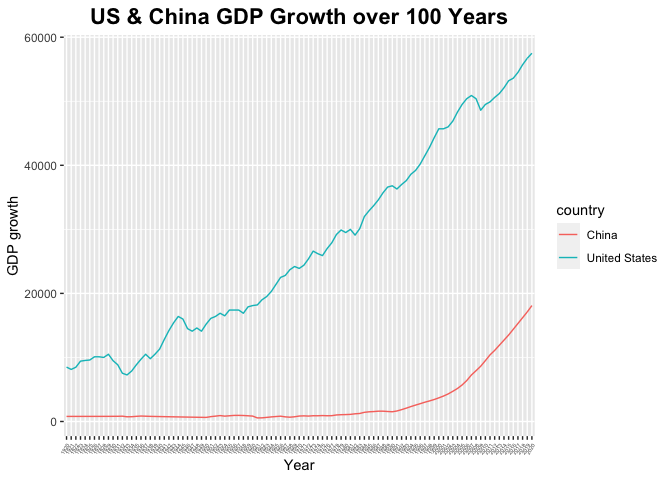

```r
gapminder_join %>%
  filter(country %in% c("China","United States")) %>%
  filter(between(year, 1920, 2020)) %>%
  ggplot(aes(x=year, y=income, group=country , color=country))+
  geom_line()+
  theme(axis.text.x = element_text(angle = 60, hjust = 1, size=4))+
  theme(plot.title = element_text(size = rel(1.5), face='bold', hjust = 0.5))+
  labs(title = "US & China GDP Growth over 100 Years",
       x = "Year",
       y = "GDP growth")
```

*China adapted with some major policy changes with leadership, military, as well as social order, as Chairman Deng Xiao- Ping started to push reform. Many notable success in foreign relations also helped the economical growth in its 1990s.*

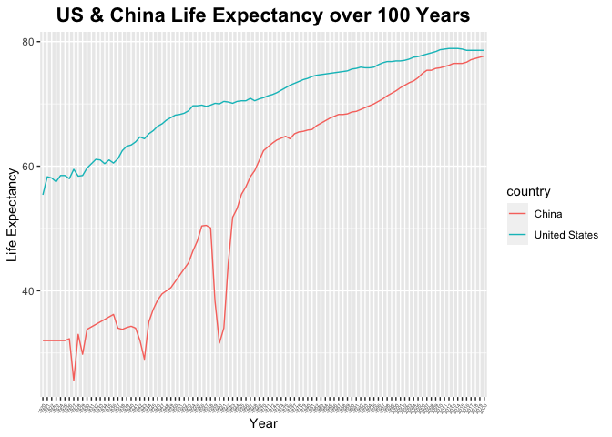

```r
gapminder_join %>%
  filter(country %in% c("China","United States")) %>%
  filter(between(year, 1920, 2020)) %>%
  ggplot(aes(x=year, y=life_expectancy, group=country , color=country))+
  geom_line()+
  theme(axis.text.x = element_text(angle = 60, hjust = 1, size=4))+
  theme(plot.title = element_text(size = rel(1.5), face='bold', hjust = 0.5))+
  labs(title = "US & China Life Expectancy over 100 Years",
       x = "Year",
       y = "Life Expectancy")
```

*The sudden drop in the life expectancy in the 1960s in China was likely due to the Great Chinese Famine, majorly contributed by inefficient distribution of food within the nation’s planned economy, requiring the use of poor agricultural techniques, over-reporting of grain production, and ordering millions of farmers to switch to iron and steel production. Causing tens of millions of people to starvation and death.*

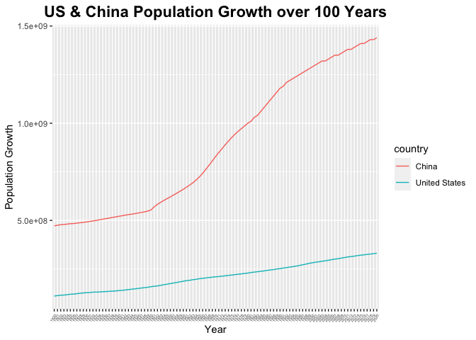

```r
gapminder_join %>%
  filter(country %in% c("China","United States")) %>%
  filter(between(year, 1920, 2020)) %>%
  ggplot(aes(x=year, y=population, group=country , color=country))+
  geom_line()+
  theme(axis.text.x = element_text(angle = 60, hjust = 1, size=4))+
  theme(plot.title = element_text(size = rel(1.5), face='bold', hjust = 0.5))+
  labs(title = "US & China Population Growth over 100 Years",
       x = "Year",
       y = "Population Growth")
```